# Epidemiology

Joseph C. Amoforitse; 2826822A@student.gla.ac.uk

2023-07-22

# Question 1

## Exploratory Data Analysis

### 1A

#### 5-number summary of BMI including the mean

| Statistic | Value |
| --- | --- |
| Minimum | 16.97531 |
| 1st Quartile | 20.06953 |
| Median | 21.91381 |
| Mean | 21.87393 |
| 3rd Quartile | 23.15556 |
| Maximum | 28.72679 |

**Commentary:** Our data is fairly symmetric with the median and mean very close together indicating that there is not many extreme values in our sample. The maximum BMI in our sample is 28.7 (kg/m2) which mean we do not have any student who is obese in our sample (BMI greater than or equal to 30)

#### Figure 1 - Histogram of BMI

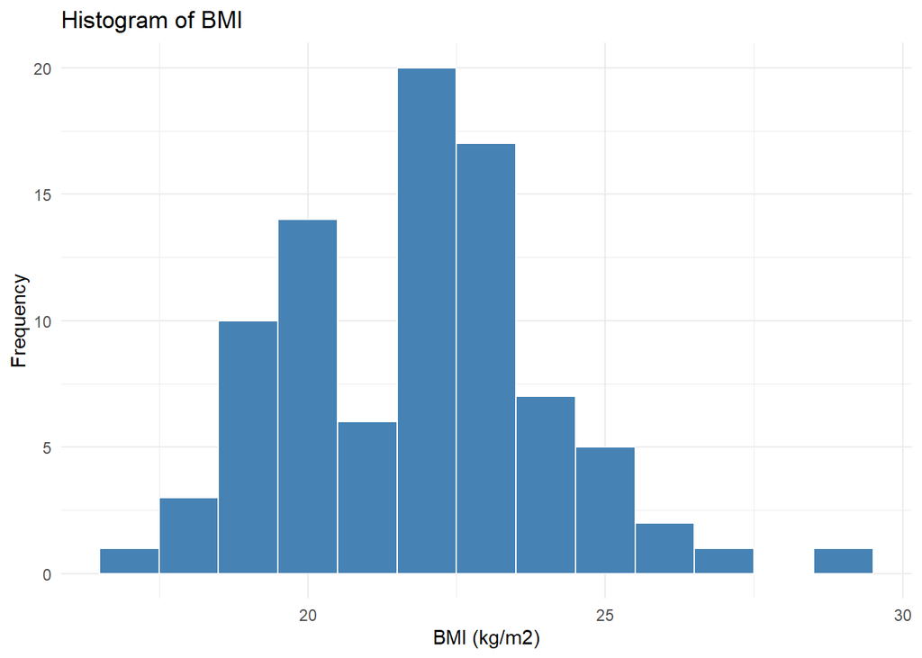

**Commentary:** The histogram supports the observation I noted above that there are not many extreme values in our sample and we have only one outlying student whose BMI is close to 30.

#### Figure 1 - Count of each BMI category for our sample

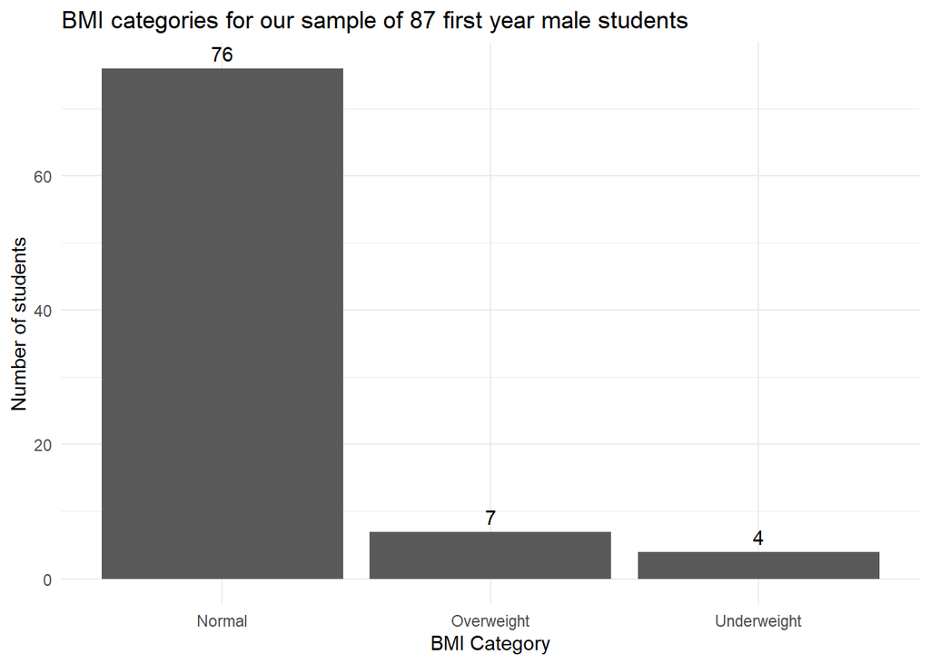

### Figure 2 - Correlation matrix between pairs of variables in our dataset

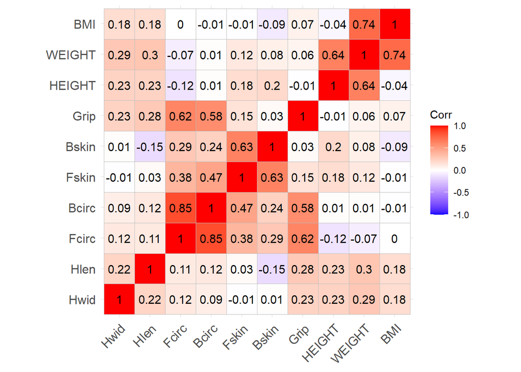

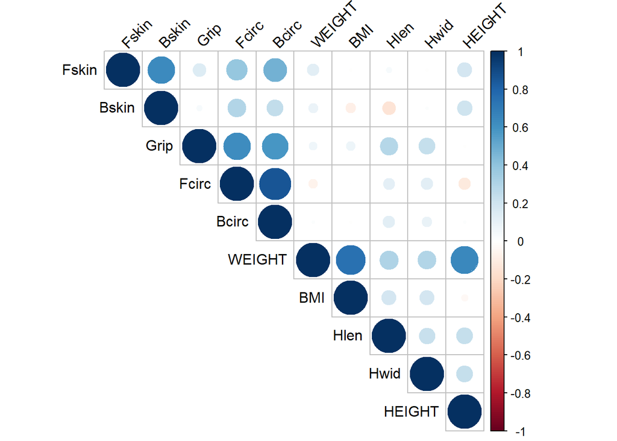

**Commentary:** Some of the variables in our dataset (predictors of grip strength) are **moderately** correlated with each other with weight and BMI being **strongly** correlated with a correlation score of 0.74. Forearm circumference and bicep circumference are also highly correlated (0.85). The implication of this is that to avoid the problem of multicollinearity in the linear regression model I aim to develop in the next section, I will only select one of the other of those variables that are highly correlated with each other.

### Regression model

#### Variable selection

I have excluded other variables due to either low correlation with the outcome variable or a medium-high correlation with variables already selected. For example, Bicep circumference has 0.85 with forecarm circumference and has been excluded to avoid multicollinearity. I decided the order for which to enter the variables in the model based on the strength of correlation.

#### Table 1 - Initial Regression Model

| Variable | Coefficient | Std.Error | t-Statistic | Prob. | Significance |
| --- | --- | --- | --- | --- | --- |
| **Intercept** | -58.92 | 15.09 | -3.90 | 0.00 | * |
| Forearm circumference | 2.74 | 0.39 | 7.03 | 0.00 | * |
| Hand length | 1.39 | 0.65 | 2.11 | 0.04 | * |
| Hand width | 0.56 | 0.40 | 1.37 | 0.17 |  |
| Weight | 0.01 | 0.08 | 0.11 | 0.91 |  |
| **R-squared** | 0.4465 | **F-statistic** | 16.54 |  |  |
| **Adjusted R-squared** | 0.4195 | **P-value** | 0.00 |  |  |

Considering that weight and hand width seem to not make any substantial contribution to our model in the presence of the other variables we included, we can drop them to get a more parsimonious model.

#### Table 2 - Final Regression Model

[output not shown]

### 1B - INTERPRETING THE MODEL RESULTS

Our model is defined as:

$$gripstrength_i = -57.74 + (2.79 forearmcircumference_i) + (1.60hand
length_i) - (1.1)$$

Both coefficients are positive and statistically significant at 0.05 confidence level which implies that higher forearm circumference yields a higher grip strength and a longer hand results in a high grip strength.

We can use the equation 1.1 above to predict the grip strength of any male student at Glasgow University **(our population)** if we have measurements of their forearm circumference and hand length by plugging the values respectively into the equation.

For example - if we consider Emeka with forearm circumference of **40.5cm** and hand length of **32.8cm**. His grip strength would = $-57.74 + (2.79*40.5) + (1.60*32.8) = 107.74kg$

### 1C - ASSUMPTIONS OF THE MODEL

Some key assumptions of the linear regression model include:

1. **Multicollinearity**: The multiple regression method assumes no strong correlation between the independent variables because this would impact our ability to interpret the model coefficients correctly. I have used a statistic called Variance Inflation Factor (VIF) to assess multicollinearity in the model. The minimum value of a VIF is 1 and it has no maximum. VIF values are assigned for every predictor in the model. Values less than 10 are not a cause for concern (Andy. F, 2012).

We can see below that our VIF values are very close to 1 and we can therefore conclude that our model is not suffering from multicollinearity and that this assumption is satisfied.

```
##    Fcirc     Hlen
## 1.011986 1.011986
```

2. **Linearity and homoscedasticity:** Linear regression assumes that the error is constant along the value of the dependent variable. We can see that both assumptions are met with the plot of fitted values versus residuals below. We can observe how the points are evenly dispersed around zero and that there is no non-linear pattern. **See plot C below.**
3. **Normality of residuals**: The Q-Q plot and histogram below does not show significant deviation of the observed residuals from normality. **See plots A and B below.**

Given that these assumptions are met, we can safely conclude that the model appears to be accurate for our sample and generalizable to the population. Forearm circumference and hand length are important in predicting grip strength.

#### Figure 3 - Plots of model output (Grip Strength = ForearmCircumference + HandLength + Error)

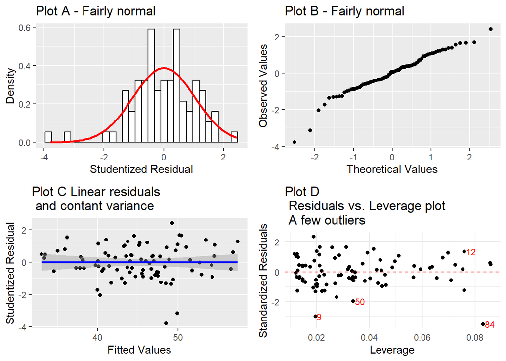

# Question 2

## 2A - Exploratory Data Analysis

### Summary statistics

```
 id
```

```
 age
```

```
 bmi
```

chd

```
chol
```

Min. : 2001

Min. :39.00

Min. :11.19

No :2897

Min. :103.0

1st Qu.: 3741

1st Qu.:42.00

1st Qu.:22.96

Yes: 257

1st Qu.:197.2

Median :11406

Median :45.00

Median :24.39

Median :223.0

Mean :10478

Mean :46.28

Mean :24.52

Mean :226.4

3rd Qu.:13115

3rd Qu.:50.00

3rd Qu.:25.84

3rd Qu.:253.0

Max. :22101

Max. :59.00

Max. :38.95

Max. :645.0

[output not shown]

[output not shown]

[output not shown]

NA’s :12

```
 dbp
```

diabetes

ncigs

```
 sbp
```

smoke

Min. : 58.00

Type A:1589

Min. : 0.0

Min. : 98.0

No :1652

1st Qu.: 76.00

Type B:1565

1st Qu.: 0.0

1st Qu.:120.0

Yes:1502

Median : 80.00

[output not shown]

Median : 0.0

Median :126.0

Mean : 82.02

[output not shown]

Mean :11.6

Mean :128.6

3rd Qu.: 86.00

[output not shown]

3rd Qu.:20.0

3rd Qu.:136.0

Max. :150.00

[output not shown]

Max. :99.0

Max. :230.0

[output not shown]

[output not shown]

[output not shown]

[output not shown]

```
Sex
```

Female:1617

Male :1537

[output not shown]

[output not shown]

[output not shown]

[output not shown]

[output not shown]

### Age and Diabetes

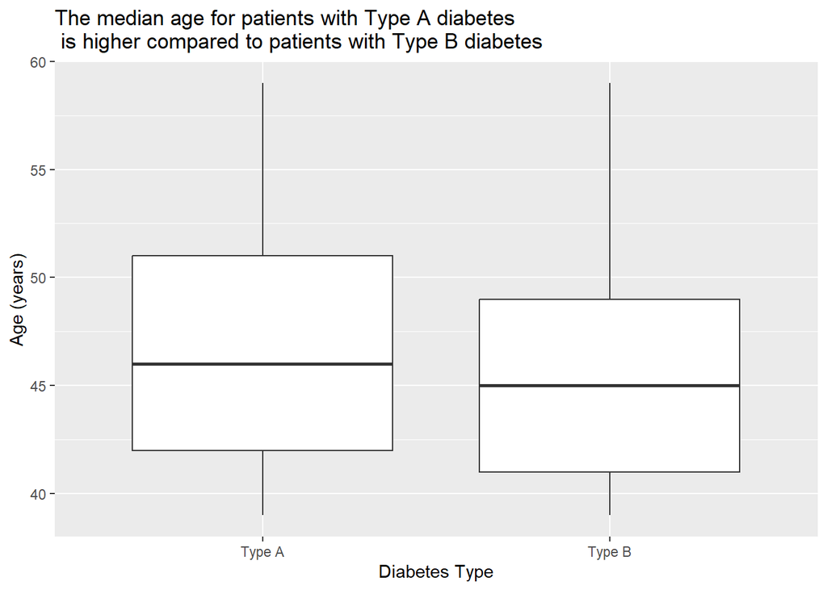

**Commentary**: As seen in the boxplots above, the median age for patients with Type A diabetes is higher compared to patients with Type B diabetes.

### BMI and Diabetes

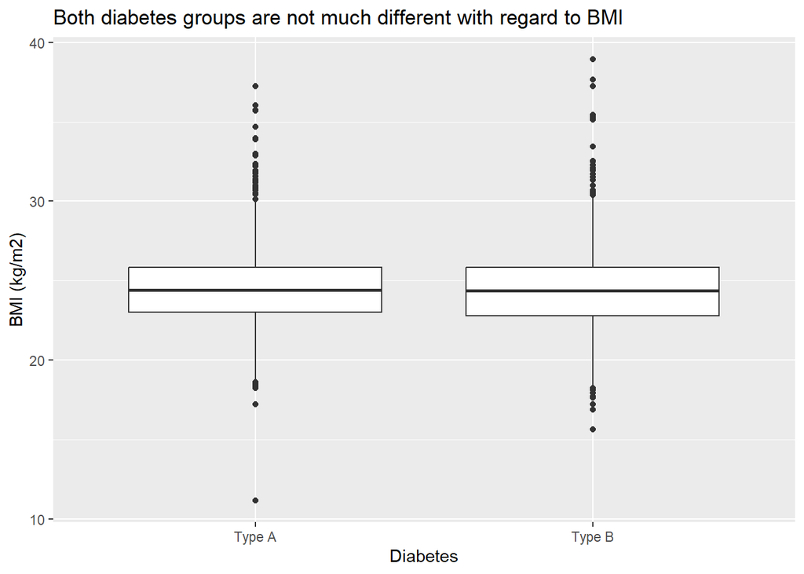

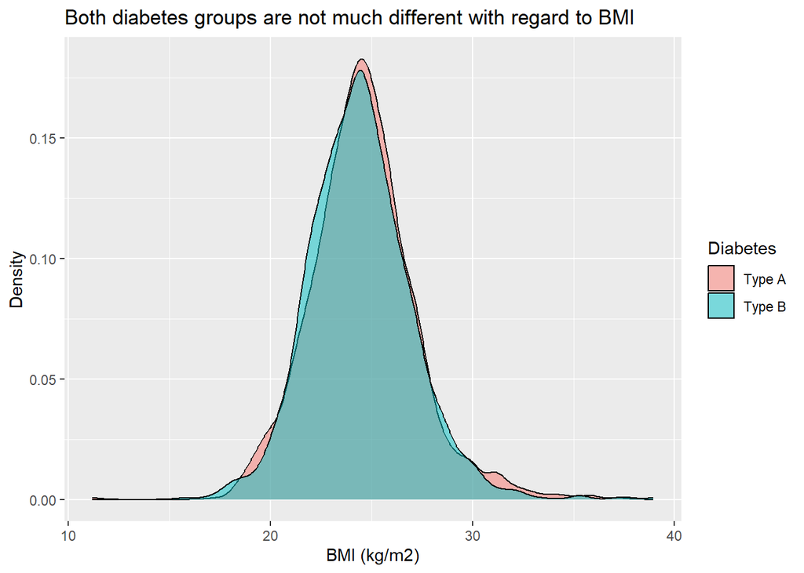

### Systolic blood pressure and Diabetes

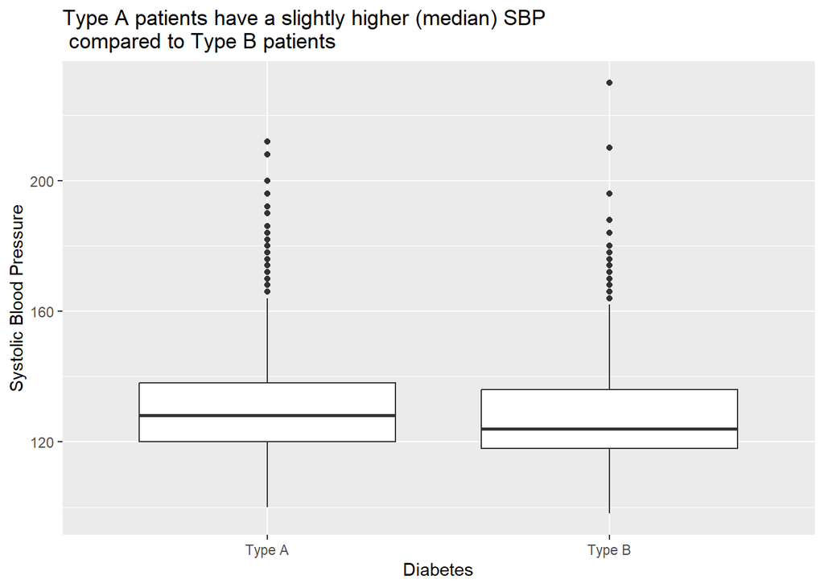

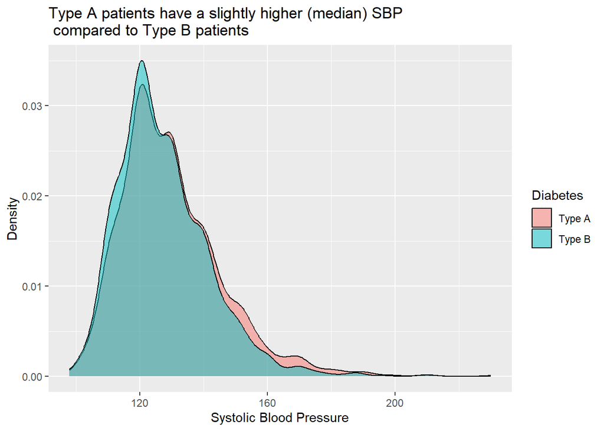

## 2B - Logistic regression models for male and female patients

### For male patients

#### Table 1. Logistic regression model result for predicting diabetes type in male patients

| Predictor | Coefficient | Std. Error | Odds Ratio | Confidence Interval | p-value |
| --- | --- | --- | --- | --- | --- |
| (Intercept) | 2.406 | 0.591 | - |  | 0.000047 |
| **Age** | -0.027 | 0.010 | 0.974 | (0.955, 0.992) | 0.005972 |
| **Patient has coronary heart disease** | -0.700 | 0.204 | 0.497 | (0.329, 0.736) | 0.000638 |
| **Number of cigarettes smoked per day** | -0.012 | 0.004 | 0.988 | (0.981, 0.994) | 0.000543 |
| **Systolic blood pressure** | -0.007 | 0.004 | 0.992 | (0.985, 0.998) | 0.025469 |

### For female patients

#### Table 2 - Logistic regression result for predicting diabetes type in female patients

| Predictor | Coefficient | Std. Error | Odds Ratio | Confidence Interval | p-value |
| --- | --- | --- | --- | --- | --- |
| (Intercept) | 1.454 | 0.426 | - |  | 0.0006 |
| **Age** | -0.027 | 0.010 | 0.973 | (0.956, 0.991) | 0.0030 |
| **Patient has coronary heart disease** | -0.723 | 0.199 | 0.485 | (0.326, 0.713) | 0.0003 |
| **Number of cigarettes smoked per day** | -0.011 | 0.004 | 0.989 | (0.982, 0.996) | 0.0024 |

## 2C - Assessment of model fit

# Appendix

## Exploratory analysis for predictor selection (Male Patients)

Here I explore which predictors are worth entering in the model by visualising if there is a noticeable difference between both diabetic groups for all the variables in our data. We can see already that there is not much difference in the cholesterol level and BMI of both diabetic groups of male patients. This is also true for whether or not one is a smoker, however it does appear to matter how many cigarette the patient smokes per day.

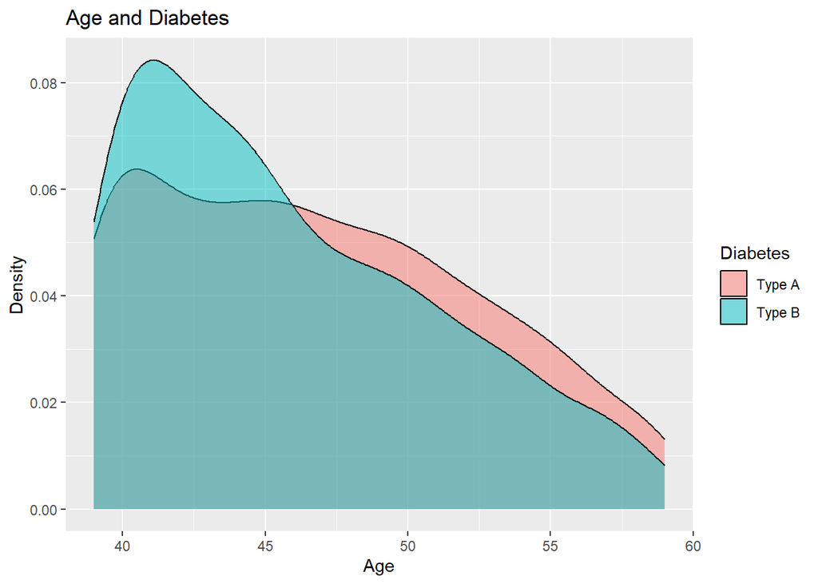

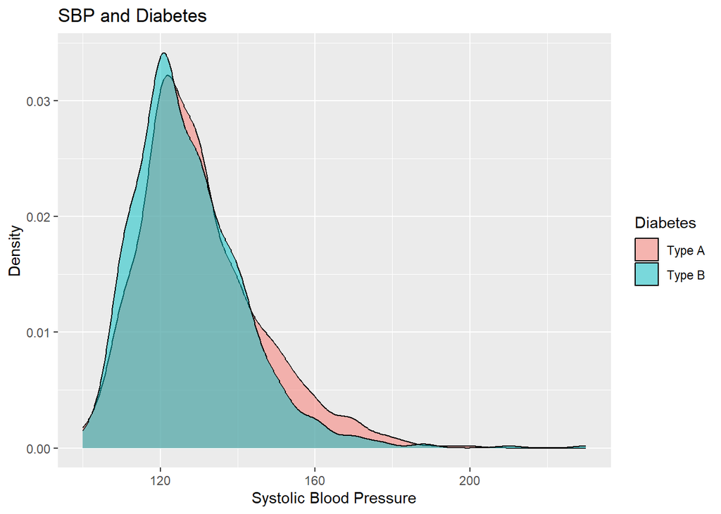

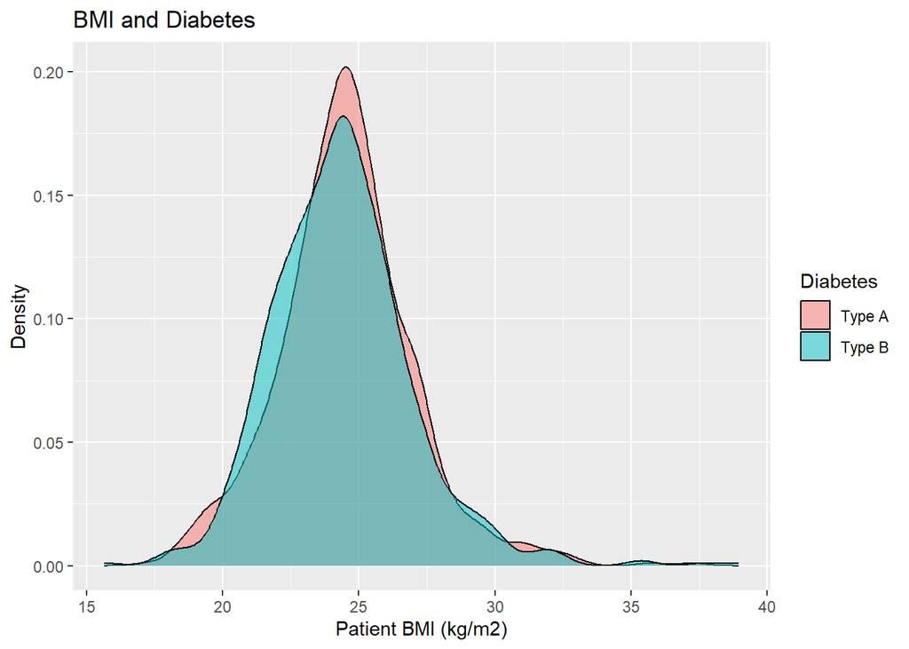

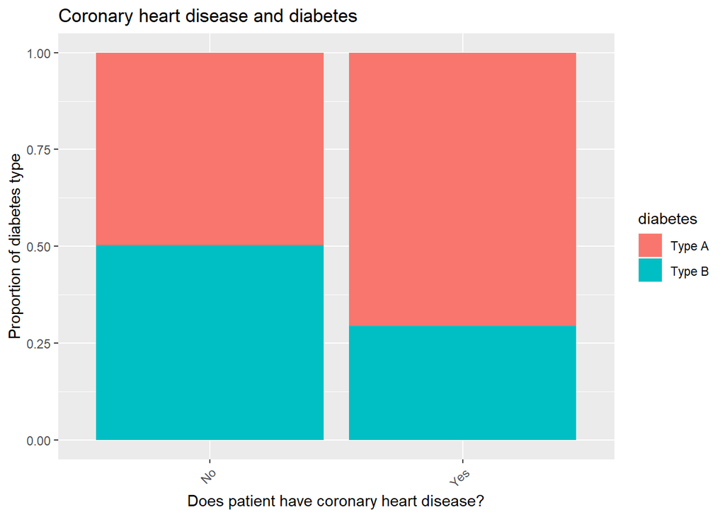

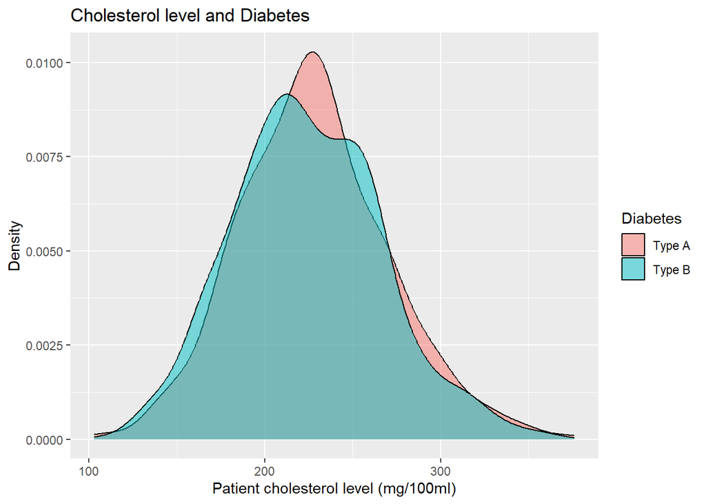

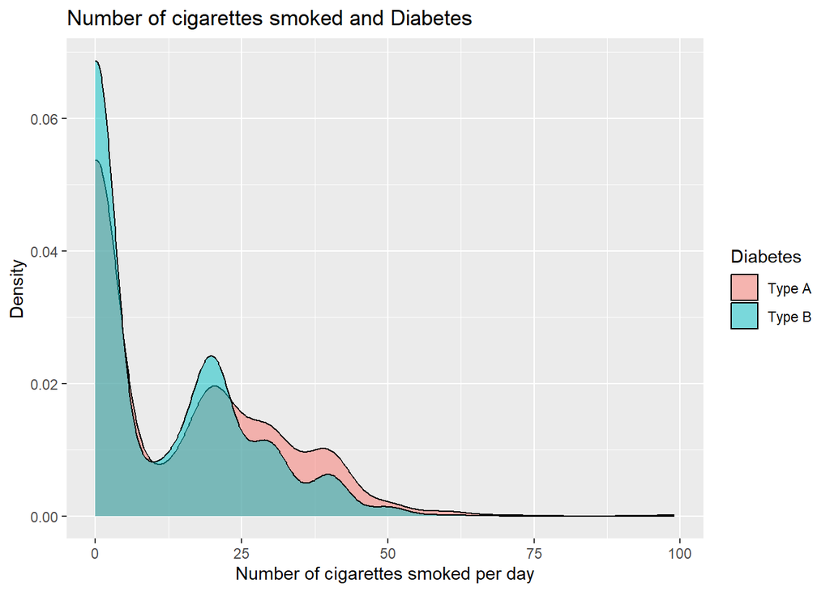

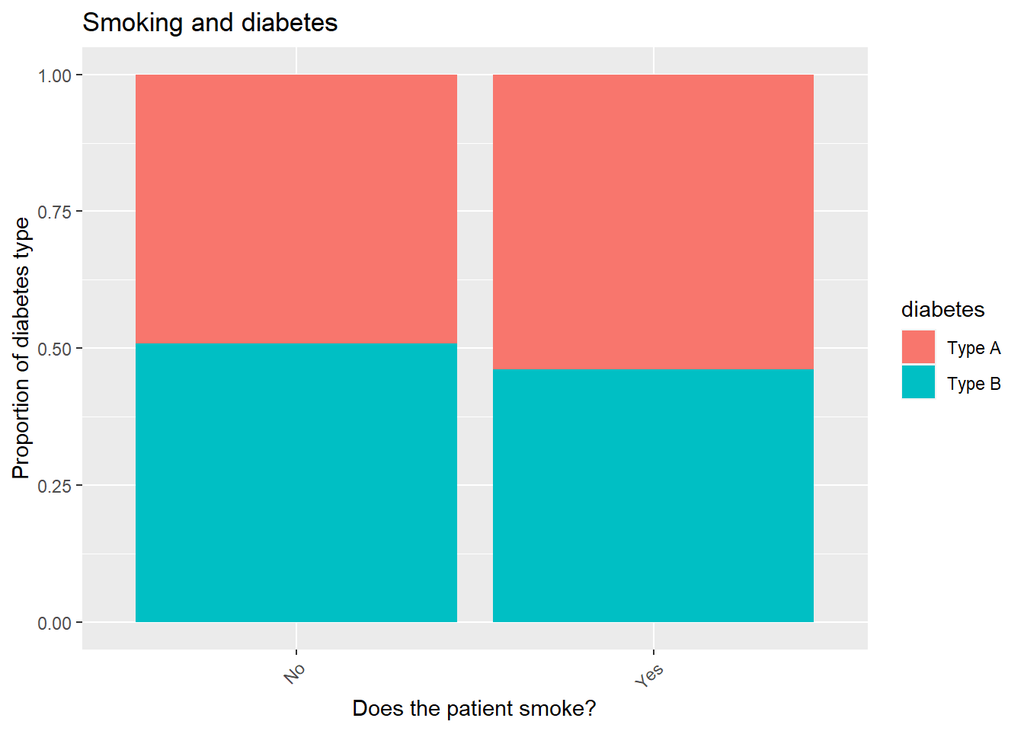

## Exploratory analysis for predictor selection (Female Patients)

Here I explore which predictors are worth entering in the model by visualising if there is a noticeable difference between both diabetic groups for all the variables in our data. We can see already that there is not much difference in the cholesterol level and BMI of both diabetic groups of female patients.

[figure not shown]

[figure not shown]

[figure not shown]

[figure not shown]

[figure not shown]

[figure not shown]

[figure not shown]

# Methodology

1. I used density plots and stacked bar charts to visualize which variables are likely to be useful predictors of patient diabetes type for each gender type. Thereafter I entered the selected variables into the regression model (6 for males), varied their position in the model to see if any changes are observed regarding the significance of the predictor or its coefficient. After this, I removed the non-significant predictors from the model at 5% level of significance to establish a parsimonious model.
2. I used systolic blood pressure and dropped diastolic blood pressure as they are both highly correlated (r = 0.77) to avoid multicollinearity.